# Class Stan Examples

STAT 341

2023-03-29

# Setup

In this document, I’m displaying the setup chunk to clarify which R packages are being used.

```r
library(tidyverse)
library(ggformula)
library(rethinking)
library(rstan)
library(CalvinBayes)
library(tidybayes)
library(bayesplot)
knitr::opts_chunk$set(echo = TRUE,
                      error = TRUE,
                      fig.width = 7,
                      fig.height = 4)

theme_set(theme_minimal(base_size = 16))
```

# Simple Normal Fit

Fit a normal distribution to the cell-phone-use-at-work data.

## Read in Phone Data

```r
phone_data  <- read_csv('https://sldr.netlify.app/data/phone_boredom.csv',
                        show_col_types = FALSE)

phone_data <- phone_data |>
  select(boredomS, fatigueS, fomo_scaled, total_b20S) |>
  rename(phone_useS = total_b20S) |>
  drop_na()
```

## Original `quap()` model

(for comparison)

```r
quap_mod <- quap(
  flist = alist(
    boredomS ~ dnorm(mu, sigma),
    mu <- dnorm(0, 0.25),
    sigma ~ dnorm(1, 1)
  ),
  data = phone_data)

# quick peek at quap results for later comparison
precis(quap_mod)
```

```
##             mean          sd        5.5%     94.5%
## mu    0.02201501 0.012896621 0.001403717 0.0426263
## sigma 0.49309811 0.009132118 0.478503223 0.5076930
```

```r
# prep data for use with stan
stan_phone_data <- compose_data(phone_data)

stan_phone_norm <- '
data {
  int<lower=1> n;         // number of observations
  vector[n] phone_useS;    // response

}
parameters {
  real<lower=0> sigma;     // std of response, single continuous value
  real mu;
}
model {
  mu ~ normal(0, 0.25);             // prior for mu
  // was: normal(120, 120) why did I change it?
  sigma ~ normal(1, 1);             // prior for sigma
  phone_useS ~ normal(mu, sigma);      // defining likelihood in terms of mus and sigma
}
'

boredom_model <- stan(model_code = stan_phone_norm,
                      data = stan_phone_data,
                      # suppress some screen printout
                      refresh = 0)
```

```
## Running MCMC with 1 chain...
```

[output not shown]

[output not shown]

[output not shown]

[output not shown]

```
## Chain 1
```

[output not shown]

[output not shown]

[output not shown]

[output not shown]

```
## Chain 1
```

```
## Chain 1 finished in 0.0 seconds.
```

```r
boredom_model
```

```
## Inference for Stan model: rt_cmdstanr_8f646884f680732021f12e5d2dc4cdf7-202303291412-1-8714d3.
## 1 chains, each with iter=1000; warmup=500; thin=1;
## post-warmup draws per chain=500, total post-warmup draws=500.
##
##         mean se_mean   sd   2.5%    25%    50%    75%  97.5% n_eff Rhat
## sigma   0.49    0.00 0.01   0.47   0.48   0.49   0.49   0.50   371    1
## mu      0.00    0.00 0.01  -0.02  -0.01   0.00   0.01   0.02   391    1
## lp__  321.91    0.06 1.03 319.39 321.43 322.21 322.68 322.93   281    1
##
## Samples were drawn using NUTS(diag_e) at Wed Mar 29 14:12:50 2023.
## For each parameter, n_eff is a crude measure of effective sample size,
## and Rhat is the potential scale reduction factor on split chains (at
## convergence, Rhat=1).
```

## Comparing with `quap()`

- We observe:

## Diagnostics

### `n_eff`

- We observe:
- Action needed?

- We observe:
- Action needed?

## Warning: Divergent Transitions?

- We observe:
- Action needed?

### Trace Plot

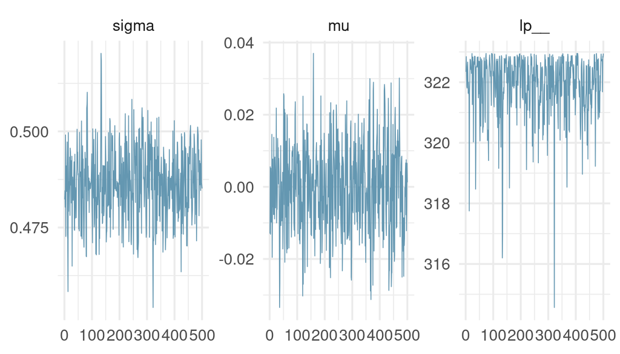

```r
bayesplot::mcmc_trace(boredom_model)
```

- We observe:
- Action needed?

### Rank Trace Plot

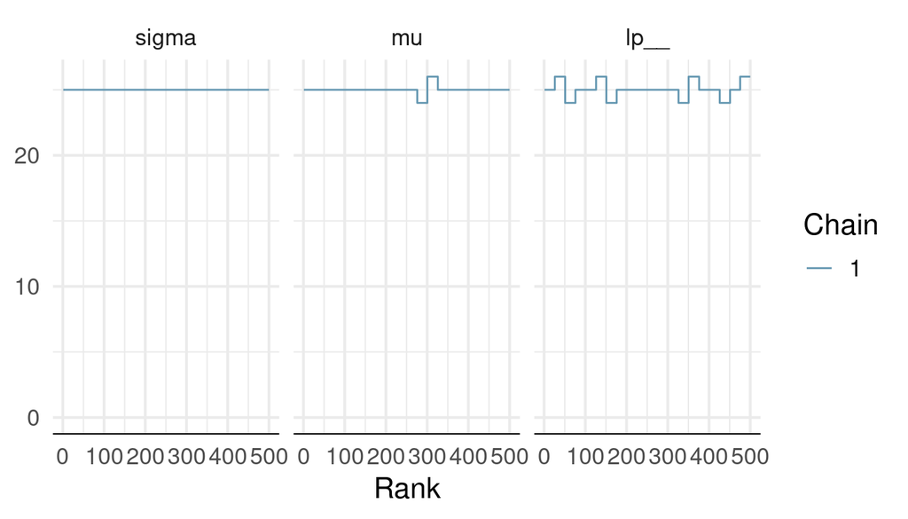

```r
bayesplot::mcmc_rank_overlay(boredom_model)
```

- We observe:
- Action needed?

# Linear Regression with Quantitative Predictor

Fit a simple linear model to the `foxes` data.

## Prepare Data

```r
# data is from rethinking package
data('foxes')
foxes <- foxes |>
  drop_na(avgfood)

# compose data for use in stan
stan_fox_data <- compose_data(foxes)
```

## Stan fit

- *Note: `quap()` fit not shown this time - you could fit it as an exercise. Author says that the posteriors are similar for `quap` and Stan.*

```r
stan_fox_regression <- '
data {
  int<lower=1> n;     // number of observations
  vector[n] weight;    // response
  vector[n] avgfood;     // predictor
}
parameters {
  real<lower=0> sigma; // std of response, single continuous value
  real a; // intercept
  real b; // slope
}
model {
  vector[n] mu; // vector of n values: expected weight for each observation
  for (i in 1:n) { // loop over the n cases in the dataset to estimate mu_i values
    mu[i] = a + b * avgfood[i];
  }
  a ~ normal(3.5, 1); // prior for intercept
  b ~ normal(5, 1); // prior forslope
  // this is probably not the same prior as used for quap()!
  sigma ~ exponential(1); // prior for sigma
  weight ~ normal(mu, sigma); // defining likelihood in terms of mus and sigma
}
'

# fit the model defined above to the stan_data
foxes_model <- stan(model_code = stan_fox_regression,
                    data = stan_fox_data,
                    chains = 4,
                    # suppress some screen printout
                    refresh = 0)
```

```
## Running MCMC with 4 sequential chains...
##
## Chain 1 finished in 0.1 seconds.
## Chain 2 finished in 0.1 seconds.
## Chain 3 finished in 0.1 seconds.
## Chain 4 finished in 0.1 seconds.
##
## All 4 chains finished successfully.
## Mean chain execution time: 0.1 seconds.
## Total execution time: 0.5 seconds.
```

```r
foxes_model
```

```
## Inference for Stan model: rt_cmdstanr_e75c891836dfea28bedfe6d89006e6c7-202303291413-1-40439f.
## 4 chains, each with iter=1000; warmup=500; thin=1;
## post-warmup draws per chain=500, total post-warmup draws=2000.
##
##         mean se_mean   sd   2.5%    25%    50%    75%  97.5% n_eff Rhat
## sigma   1.22    0.00 0.08   1.08   1.17   1.22   1.28   1.39   599 1.00
## a       3.66    0.01 0.37   2.93   3.41   3.67   3.90   4.38   736 1.01
## b       1.16    0.02 0.48   0.22   0.84   1.15   1.48   2.08   723 1.01
## lp__  -89.73    0.04 1.21 -92.68 -90.34 -89.43 -88.82 -88.32   727 1.00
##
## Samples were drawn using NUTS(diag_e) at Wed Mar 29 14:13:01 2023.
## For each parameter, n_eff is a crude measure of effective sample size,
## and Rhat is the potential scale reduction factor on split chains (at
## convergence, Rhat=1).
```

## Comparing with `quap()`

- We observe:

## Diagnostics

### `n_eff`

- We observe:
- Action needed?

- We observe:
- Action needed?

## Warning: Divergent Transitions?

- We observe:
- Action needed?

### Trace Plot

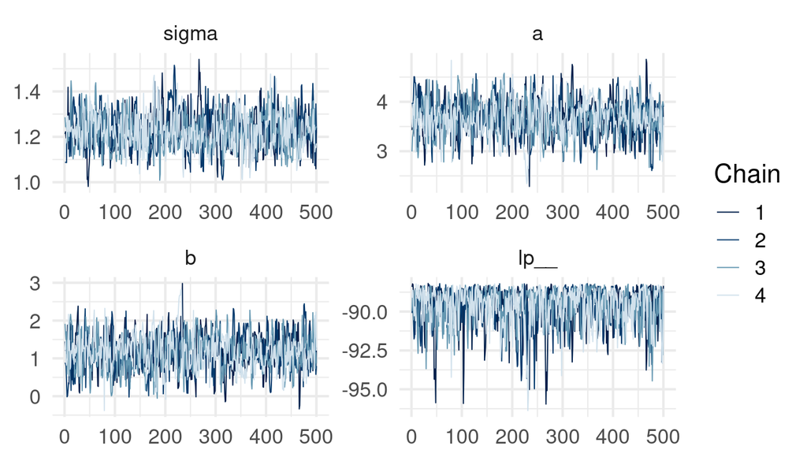

```r
bayesplot::mcmc_trace(foxes_model)
```

- We observe:
- Action needed?

### Rank Trace Plot

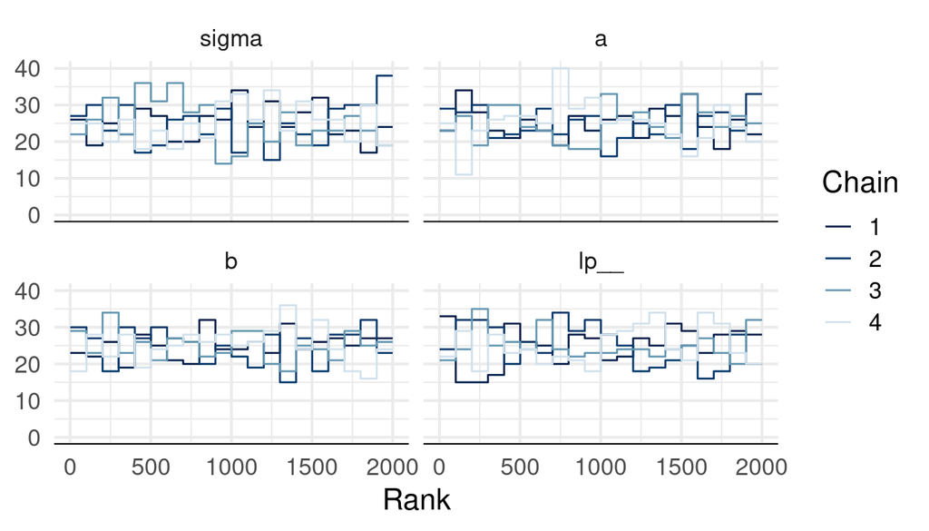

```r
bayesplot::mcmc_rank_overlay(foxes_model)
```

- We observe:
- Action needed?

# Regression with Multiple Quantitative Predictors

This is an analysis of the data on bug diversity in houses and how it relates to residents’ socioeconomic status.

## Read in Data

```r
bugs <- read_csv('https://sldr.netlify.app/data/house_bugs.csv',
                 show_col_types = FALSE) |>
  na.omit()

bugs <- bugs |>
  mutate(arthropod_div = arthropod.div) |>
  mutate(income_avg_z = income.avg.z) |>
  mutate(sqft_z = sqft.z) |>
  mutate(total_value_z = total.value.z)

stan_bug_data <- compose_data(bugs)
```

## Original `quap()` model

(for comparison)

```r
model_descrip <- alist(
  arthropod.div ~ dnorm(mu, sigma),
  mu ~ beta0 + beta1 * income.avg.z + beta2 * total.value.z + beta3 * sqft.z,
  beta0 ~ dnorm(mean = 20, sd = 10),
  beta1 ~ dnorm(mean = 25, sd = 5),
  beta2 ~ dnorm(mean = 25, sd = 5),
  beta3 ~ dnorm(mean = 10, sd = 10),
  sigma ~ dnorm(mean = 20, sd = 5)
)

quap_bug_model <- quap(flist = model_descrip,
                       data = bugs)
quap_bug_post_sample <- extract.samples(quap_bug_model, n = 1000)
precis(quap_bug_model)
```

```
##            mean       sd      5.5%     94.5%
## beta0 45.125448 2.519168 41.099331 49.151565
## beta1  8.528266 2.465026  4.588679 12.467853
## beta2 11.015292 3.129883  6.013135 16.017449
## beta3 -3.195204 3.366083 -8.574854  2.184446
## sigma 18.059236 1.911905 15.003643 21.114829
```

## Fit Model in Stan

```r
stan_bug_program <- '
data {
// number of observations
int<lower=1> n;
// response
vector[n] arthropod_div;
// predictor
vector[n] income_avg_z;
// predictor
vector[n] sqft_z;
// predictor
vector[n] total_value_z;
}
parameters {
// std of response, single continuous value
real<lower=0> sigma;
real a;
real b;
real c;
real d;
}
model {
// vector of n values: expected arthropod.div for each observation
vector[n] mu;
// loop over the n cases in the dataset to estimate mu_i values
for (i in 1:n) {
mu[i] = a + (b*income_avg_z[i]) + (c*total_value_z[i]) + (d*sqft_z[i]);
}
// prior for intercept
a ~ normal(20, 10);
// priors for slopes
b ~ normal(25, 5);
c ~ normal(25, 5);
d ~ normal(10, 10);
// prior for sigma
sigma ~ normal(20, 5);
// defining likelihood in terms of mus and sigma
arthropod_div ~ normal(mu, sigma);
}
'
```

```r
# we are using an unusually small number of warmup iterations to see what goes wrong
bug_stan_model <- stan(model_code = stan_bug_program,
                       data = stan_bug_data,
                       chains = 4,
                       warmup = 25,
                       refresh = 0)
```

```
## Running MCMC with 4 sequential chains...
##
## Chain 1 WARNING: There aren't enough warmup iterations to fit the
## Chain 1          three stages of adaptation as currently configured.
## Chain 1          Reducing each adaptation stage to 15%/75%/10% of
## Chain 1          the given number of warmup iterations:
## Chain 1            init_buffer = 3
## Chain 1            adapt_window = 20
## Chain 1            term_buffer = 2
## Chain 1 finished in 7.1 seconds.
## Chain 2 WARNING: There aren't enough warmup iterations to fit the
## Chain 2          three stages of adaptation as currently configured.
## Chain 2          Reducing each adaptation stage to 15%/75%/10% of
## Chain 2          the given number of warmup iterations:
## Chain 2            init_buffer = 3
## Chain 2            adapt_window = 20
## Chain 2            term_buffer = 2
## Chain 2 finished in 1.9 seconds.
## Chain 3 WARNING: There aren't enough warmup iterations to fit the
## Chain 3          three stages of adaptation as currently configured.
## Chain 3          Reducing each adaptation stage to 15%/75%/10% of
## Chain 3          the given number of warmup iterations:
## Chain 3            init_buffer = 3
## Chain 3            adapt_window = 20
## Chain 3            term_buffer = 2
```

[output not shown]

[output not shown]

[output not shown]

[output not shown]

```
## Chain 3
```

[output not shown]

[output not shown]

[output not shown]

[output not shown]

```
## Chain 3
```

```
## Chain 3 finished in 1.9 seconds.
## Chain 4 WARNING: There aren't enough warmup iterations to fit the
## Chain 4          three stages of adaptation as currently configured.
## Chain 4          Reducing each adaptation stage to 15%/75%/10% of
## Chain 4          the given number of warmup iterations:
## Chain 4            init_buffer = 3
## Chain 4            adapt_window = 20
## Chain 4            term_buffer = 2
## Chain 4 finished in 1.9 seconds.
##
## All 4 chains finished successfully.
## Mean chain execution time: 3.2 seconds.
## Total execution time: 12.9 seconds.
```

```r
bug_stan_model
```

```
## Inference for Stan model: rt_cmdstanr_5d1b7bdcfb70c43a5c5ae84e5f6d70a0-202303291413-1-545131.
## 4 chains, each with iter=1000; warmup=25; thin=1;
## post-warmup draws per chain=975, total post-warmup draws=3900.
##
##          mean se_mean     sd    2.5%     25%     50%     75%   97.5% n_eff Rhat
## sigma   19.13    0.14   2.65   15.32   17.62   18.91   20.46   24.39   366 1.00
## a       44.21    0.93   5.75   37.31   43.08   44.95   46.70   49.86    38 1.08
## b        8.66    0.17   2.79    3.27    6.92    8.72   10.45   13.93   282 1.01
## c       11.14    0.20   3.32    4.41    9.02   11.16   13.30   17.79   265 1.01
## d       -3.21    0.18   3.58  -10.25   -5.50   -3.23   -0.88    3.84   376 1.01
## lp__  -188.94   12.74 137.07 -184.35 -179.56 -178.32 -177.51 -176.56   116 1.02
##
## Samples were drawn using NUTS(diag_e) at Wed Mar 29 14:13:24 2023.
## For each parameter, n_eff is a crude measure of effective sample size,
## and Rhat is the potential scale reduction factor on split chains (at
## convergence, Rhat=1).
```

## Comparing with `quap()`

If we wanted a more in-depth comparison, we could plot the posterior density for parameter(s), overlaying results from `quap()` and `stan()`. Usually we need not do this as we would not fit the same model using 2 different algorithms - we are doing it now as a way of checking that our first attempt to fit a model in `stan()` was not buggy and fitted the model we intended!

Example for parameter `a`:

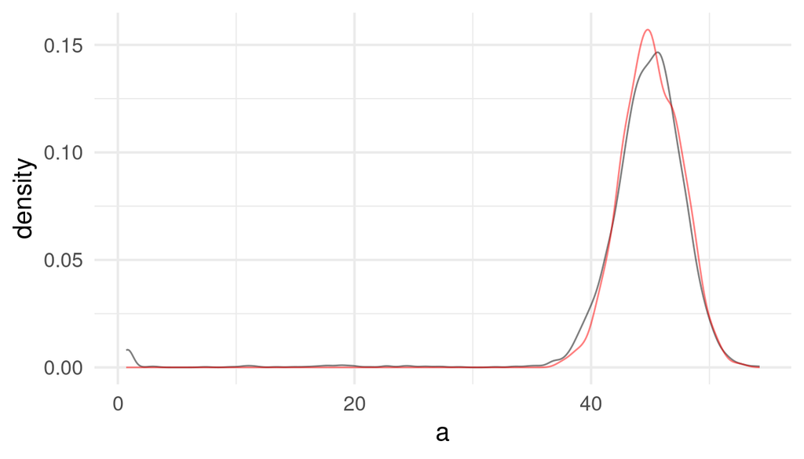

```r
# get posterior sample from stan fitted model
psamp <- as.data.frame(bug_stan_model)
gf_dens(~a, data = psamp) |>
  gf_dens(~beta0, data = quap_bug_post_sample,
          color = 'red',
          inherit = FALSE)
```

- We observe:

## Diagnostics

### `n_eff`

- We observe:
- Action needed?

- We observe:
- Action needed?

## Warning: Divergent Transitions?

- We observe:
- Action needed?

### Trace Plot

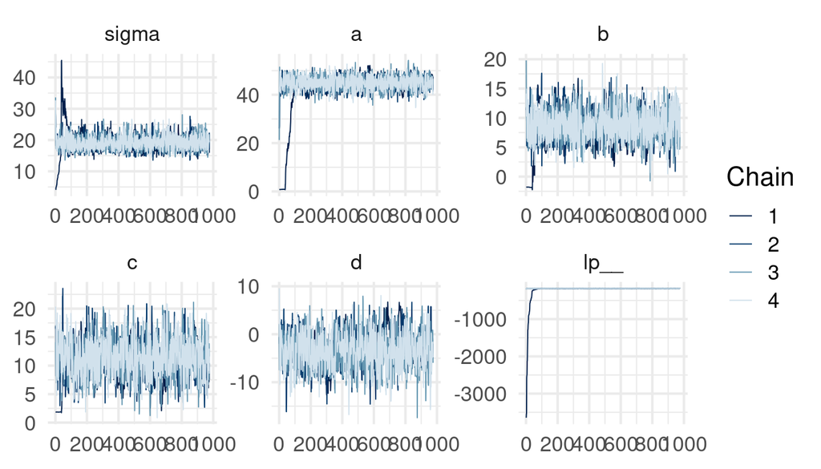

```r
bayesplot::mcmc_trace(bug_stan_model)
```

- We observe:
- Action needed?

### Rank Trace Plot

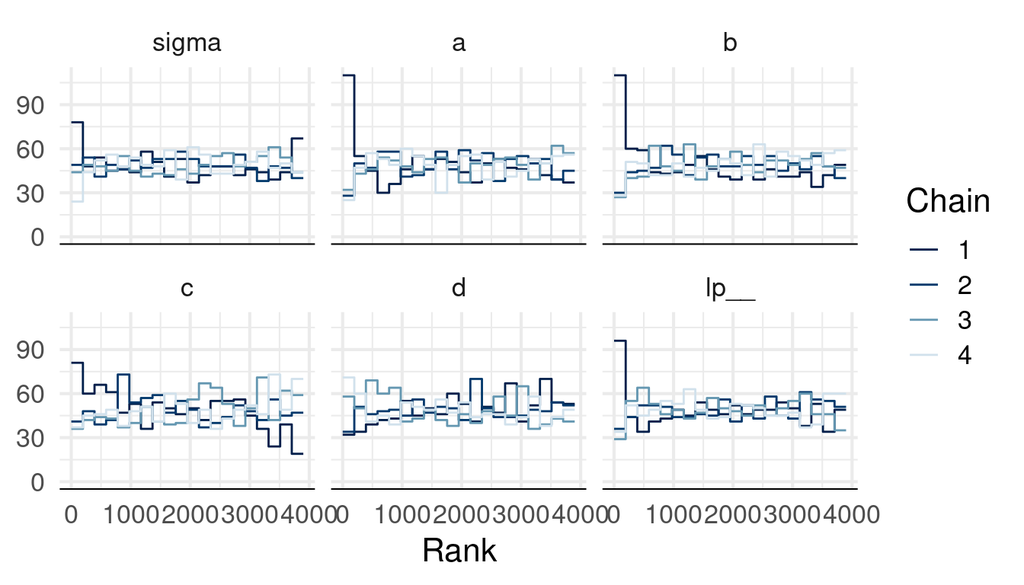

```r
bayesplot::mcmc_rank_overlay(bug_stan_model)
```

- We observe:
- Action needed?

# Regression with Interacting Categorical Predictors

We’re fitting a model to the `Wines2012` data from the `rethinking` package, with 2 *interacting* categorical predictors.

(If they *were not* interacting, we’d likely formulate the model with two separate categorical predictors instead of one “combo” categorical predictor comprising all combinations of the two categories. Code would look a lot like the code shown here, except with two categorical predictors instead of one!)

## Read in Data

```r
data("Wines2012")
Wines2012 <- Wines2012 |>
  mutate(# make a standardized version of the score variable
    score_std = as.numeric(scale(score)),
    # categorical versions of some variables originally coded 0/1
    wine.origin = ifelse(wine.amer == 1, 'USA', 'Other'),
    judge.nationality = ifelse(judge.amer == 1, 'USA', 'France'),
    # numeric index versions of the same categorical variables
    origin.ix = as.numeric(factor(wine.origin)),
    judge.ix = as.numeric(factor(judge.nationality))
  )

# we'd use this if we wanted the categorical predictors to interact.
# for model without interaction, we won't need it.
Wines2012 <- Wines2012 |>
  mutate(Origin_Judge = interaction(wine.origin, judge.nationality),
         Origin_Judge_ix = as.numeric(Origin_Judge)) |>
  drop_na(Origin_Judge, score_std)

stan_wine_data <- compose_data(Wines2012)

levels(Wines2012$Origin_Judge)
```

```
## [1] "Other.France" "USA.France"   "Other.USA"    "USA.USA"
```

## Original `quap()` model

(for comparison)

```r
wine_model_list <- alist(
  score_std ~ dnorm(mu, sigma),
  mu <- b1[Origin_Judge_ix],
  b1[Origin_Judge_ix] ~ dnorm(0, 0.25),
  sigma ~ dlnorm(0,1)
)

wine_int_model <- quap(
  flist = wine_model_list,
  data = Wines2012
)

precis(wine_int_model, depth = 2)
```

```
##               mean         sd        5.5%      94.5%
## b1[1] -0.042743305 0.14267667 -0.27076817 0.18528156
## b1[2] -0.142594502 0.12343196 -0.33986261 0.05467361
## b1[3]  0.186149822 0.13209034 -0.02495606 0.39725570
## b1[4]  0.009964391 0.11314291 -0.17085983 0.19078862
## sigma  0.982810038 0.05165549  0.90025458 1.06536549
```

```r
wine_stan_program <- '
data {
// number of observations
int<lower=1> n;
// response
vector[n] score_std;
// categorical predictor,"Other.France" or "USA.France" or "Other.USA" or   "USA.USA"
array[n] int Origin_Judge;

}
parameters {
// std of response, single continuous value
real<lower=0> sigma;
// vector of 4 numeric values: expected scores for each combo of wine origin & judge origin
vector[4] a;
}

model {
// vector of n values: expected score_std for each observation
vector[n] mu;
// loop over the n cases in the dataset to estimate mu_i values
for (i in 1:n) {
// expected score_std is judge- and wine-origin-specific value
mu[i] = a[Origin_Judge[i]];
}
// THESE PRIORS ARE INTENTIONALLY AWFULLY UNINFORMATIVE
// (WHAT WILL GO WRONG?)
// prior for all four intercepts
a ~ normal(50, 250);
// prior for sigma
sigma ~ lognormal(1,1000);
// defining likelihood in terms of mus and sigma
score_std ~ normal(mu, sigma);
}
'

wine_stan_model <- stan(model_code = wine_stan_program,
                     data = stan_wine_data,
                     chains = 4,
                     warmup = 100)
```

[output not shown]

[output cut: 31 more lines]

[output not shown]

- Note: if you want to use a lognormal distribution for a prior, you need to know what Stan’s function for that distribution is. Remember, there is a reference manual for that: https://mc-stan.org/docs/functions-reference/continuous-distributions.html. We find that Stan uses `lognormal()`.

```r
wine_stan_model
```

```
## Inference for Stan model: rt_cmdstanr_6260d94bc3cb507a35f49658f74a7157-202303291413-1-04e22c.
## 4 chains, each with iter=1000; warmup=100; thin=1;
## post-warmup draws per chain=900, total post-warmup draws=3600.
##
##         mean se_mean   sd   2.5%    25%    50%    75%  97.5% n_eff Rhat
## sigma   1.00    0.00 0.05   0.90   0.96   1.00   1.03   1.11  4657    1
## a[1]   -0.06    0.00 0.18  -0.41  -0.18  -0.06   0.06   0.29  2631    1
## a[2]   -0.19    0.00 0.15  -0.47  -0.28  -0.18  -0.09   0.10  2698    1
## a[3]    0.26    0.00 0.16  -0.05   0.15   0.26   0.37   0.57  3303    1
## a[4]    0.01    0.00 0.13  -0.25  -0.08   0.01   0.10   0.26  3949    1
## lp__  -90.77    0.04 1.64 -94.98 -91.56 -90.46 -89.58 -88.61  1424    1
##
## Samples were drawn using NUTS(diag_e) at Wed Mar 29 14:13:36 2023.
## For each parameter, n_eff is a crude measure of effective sample size,
## and Rhat is the potential scale reduction factor on split chains (at
## convergence, Rhat=1).
```

## Comparing with `quap()`

- We observe:

## Diagnostics

### `n_eff`

- We observe:
- Action needed?

- We observe:
- Action needed?

## Warning: Divergent Transitions?

- We observe:
- Action needed?

### Trace Plot

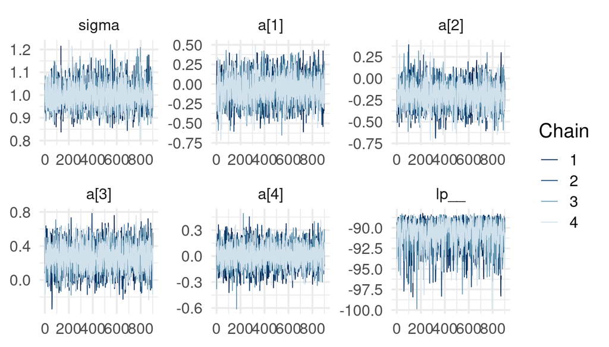

```r
bayesplot::mcmc_trace(wine_stan_model)
```

- We observe:
- Action needed?

### Rank Trace Plot

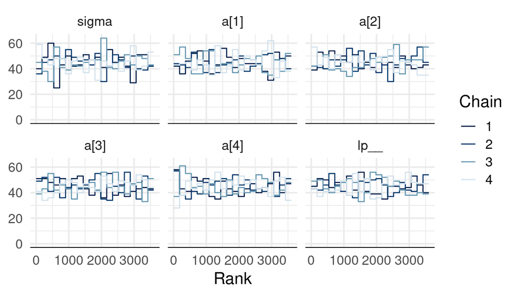

```r
bayesplot::mcmc_rank_overlay(wine_stan_model)
```

- We observe:
- Action needed?